# Milestone report: Exploratory Data analysis of English corpus

Sergio Garcia Busto

2022-10-04

## Introduction

Modern keyboards have built-in text predictor algorithms in order to ease the writing process of the user. Besides, these algorithms are also used in a variety of industries. The objective of the Capstone Project is to predict the next word based on the preceding word(s) using a large text dataset collected from Twitter, blogs, and news (raw data: https://d396qusza40orc.cloudfront.net/dsscapstone/dataset/Coursera-SwiftKey.zip. This report intends to outline the Exploratory Data Analysis performed prior to building a prediction model. The datasets from three sources (Twitter, blogs and news) will be briefly explored and data will be combined, tokenized and analysed via unigrams and bigrams.

## Data wrangling and tokenization

Data loading and corpus creation is done as a first step:

```r
#Packages
library(stringr)
library(dplyr)
```

```r
library(readr)
library(ggplot2)
library(quanteda)
library(readtext)
library(data.table)
library(quanteda.textplots)
library(quanteda.textstats)
set.seed(156465)

#Data loading and corpus creation
twitter<-read_lines("en_US.twitter.txt")
tw<-data.table(twitter)
tw.df<-data.frame(tw)
tw.s<-sample(tw.df$twitter, 15000)
tw.c<-corpus(tw.s)

news<-read_lines("en_US.news.txt")
nw<-data.table(news)
nw.fr<-data.frame(nw)
nw.s<-sample(nw.fr$news, 15000)
nw.c<-corpus(nw.s)

blogs<-read_lines("en_US.blogs.txt")
bl<-data.table(blogs)
bl.fr<-data.frame(bl)
bl.s<-sample(bl.fr$blogs, 15000)
bl.c<-corpus(bl.s)
```

Document names should also be updated for combining datasets from different sources into a big corpus:

```r
docnames(bl.c)<-paste("bl", 1:15000, sep = ".")
docnames(nw.c)<-paste("nw", 1:15000, sep = ".")
docnames(tw.c)<-paste("tw", 1:15000, sep = ".")
```

Moreover, a list of profanities is loaded for removal during tokenization.

```r
bad<-read.table("list.txt", sep = "\n")
bad<-as.character(bad$V1)
```

Data merging and tokenization of the total corpus is conducted below to form two objects, with and without common English words. The tokens with common words will be eventually used, as these words will also need to be predicted. The source will also be included for comparison.

```r
#tokenizing total, appointing source for comparison
total.corpus<-tw.c+nw.c+bl.c
docvars(total.corpus, "source")<-c(rep("twitter",15000), rep("news", 15000), rep("blogs", 15000))
tok<-total.corpus %>%
  tokens(remove_punct = TRUE,
         remove_symbols = TRUE,
         remove_numbers = TRUE,
         remove_url = TRUE,
         split_hyphens = TRUE) %>%
  tokens_remove(bad) %>%
  tokens_keep(pattern = "^[a-zA-Z]+$", valuetype = "regex")

tok.st<-total.corpus %>%
  tokens(remove_punct = TRUE,
         remove_symbols = TRUE,
         remove_numbers = TRUE,
         remove_url = TRUE,
         split_hyphens = TRUE) %>%
  tokens_remove(bad) %>%
  tokens_remove(stopwords("english")) %>%
  tokens_keep(pattern = "^[a-zA-Z]+$", valuetype = "regex")
```

Finally, unigrams and bigrams (and corresponding document feature matrices) will be created for analysis.

```r
#unigrams and dfms
unig_tok<-tokens_ngrams(tok, n=1)
unig.st_tok<-tokens_ngrams(tok.st, n=1)
unig_dfm<-dfm(unig_tok)
unig.st_dfm<-dfm(unig.st_tok)

unig2_tok<-tokens_ngrams(tok, n=2)
unig2_dfm<-dfm(unig2_tok)
```

## Exploratory Data Analysis (EDA)

```r
data.table(Source=c("Twitter", "News", "Blogs"), Words=c(sum(str_length(tw.c)), sum(str_length(nw.c)), sum(str_length(bl.c))), Lines=c(dim(tw), dim(nw), dim(bl)))
```

```
##     Source   Words   Lines
## 1: Twitter 1031690 2360148
## 2:    News 3031296       1
## 3:   Blogs 3484911 1010242
## 4: Twitter 1031690       1
## 5:    News 3031296  899288
## 6:   Blogs 3484911       1
```

The most common words can also be quickly displayed, which shows that some key common words, like “the”, are used the most.

```r
#topfeatures
topfeatures(unig_dfm, 20)
```

```
##   the    to   and     a    of    in     i  that    is   for    it    on  with
## 66574 36362 34794 32237 28723 22601 20166 14431 13828 13723 11880 10573  9809
##   you   was    at  this    my    be    as
##  9704  8868  7470  7460  7116  7002  6989
```

```r
topfeatures(unig.st_dfm, 20)
```

```
##   said    one   just   like    can   time    get    new    now people   year
##   4452   4086   3396   3258   3167   2848   2524   2398   2122   2004   1976
##   also    day   good   know  first   back    two   make     go
##   1928   1922   1906   1903   1899   1796   1774   1610   1607
```

As a sidenote, the context of the words can also be checked:

```r
#see context of words
kwic(bl.c, "communist*")
```

```
## Keyword-in-context with 14 matches.
##    [bl.693, 26]     read and write from his | communist  |
##   [bl.1360, 64] matched by one hunting down | Communist  |
##  [bl.2778, 143]      ," even socialists and | Communists |
##   [bl.3826, 13]           " I salute the SA | Communist  |
##    [bl.3921, 4]               The ultimate" | Communist  |
##  [bl.4003, 159]         2 ) and the Eastern | Communist  |
##   [bl.5418, 43]   was" secretly financed by | Communists |
##    [bl.8642, 5]        His support of other | communist  |
##   [bl.8642, 24]    in Cuba to celebrate the | communist  |
##   [bl.8902, 36]    to kowtow to the Chinese | Communist  |
##  [bl.10891, 40]  ANC has inherited from the | communists |
##  [bl.13204, 50]     the degree to which the | Communist  |
##   [bl.14024, 7]   October 2000, top Chinese | Communist  |
##   [bl.14417, 4]                Epoch Times: | Communist  |
##
##  warlord and mass murderer buddy
##  mass murderers. ) However
##  of all enemy countries support
##  Party for its steady contribution
##  monument," then,
##  propaganda. So their land
##  "?". The
##  dictatorships is blatant. In
##  revolution with Fidel Castro.
##  Party for our economic advantage
##  and implemented with absolute results
##  Party of China is self-aware
##  Party leader Jiang Zemin ordered
##  officials profit immensely from their
```

Wordclouds can be constructed for visualising the most common words:

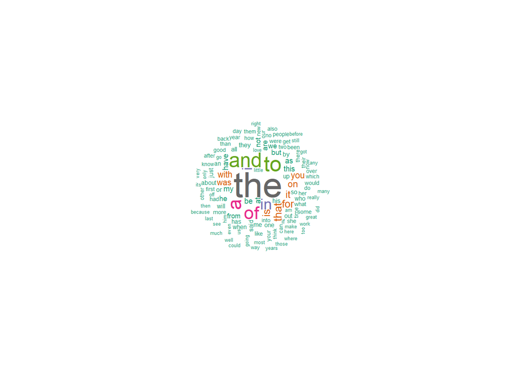

```r
#wordcloud
textplot_wordcloud(unig_dfm, min_count=1200, random_order= FALSE, rotation = .25, color = RColorBrewer::brewer.pal(8, "Dark2"), labelsize = 10)
```

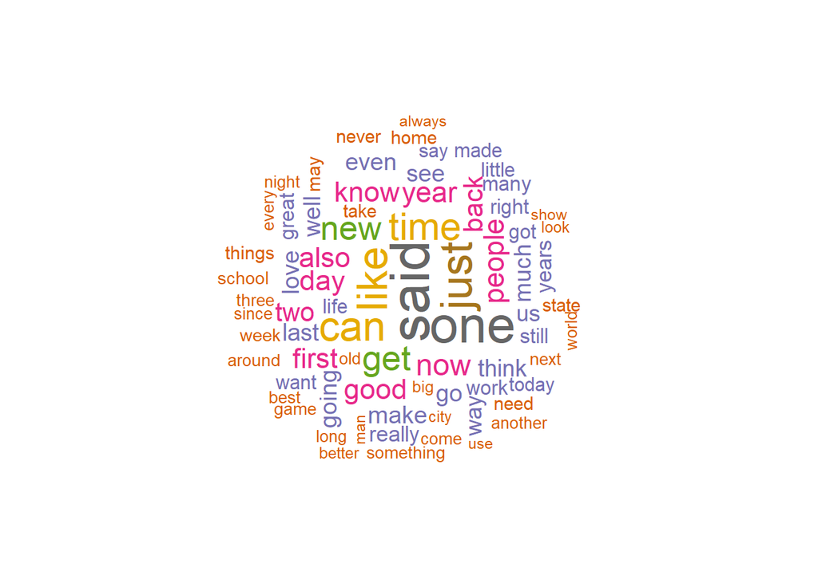

```r
textplot_wordcloud(unig.st_dfm, min_count=750, random_order= FALSE, rotation = .25, color = RColorBrewer::brewer.pal(8, "Dark2"), labelsize = 10)
```

And the same can be done with pairs of words using the bigram:

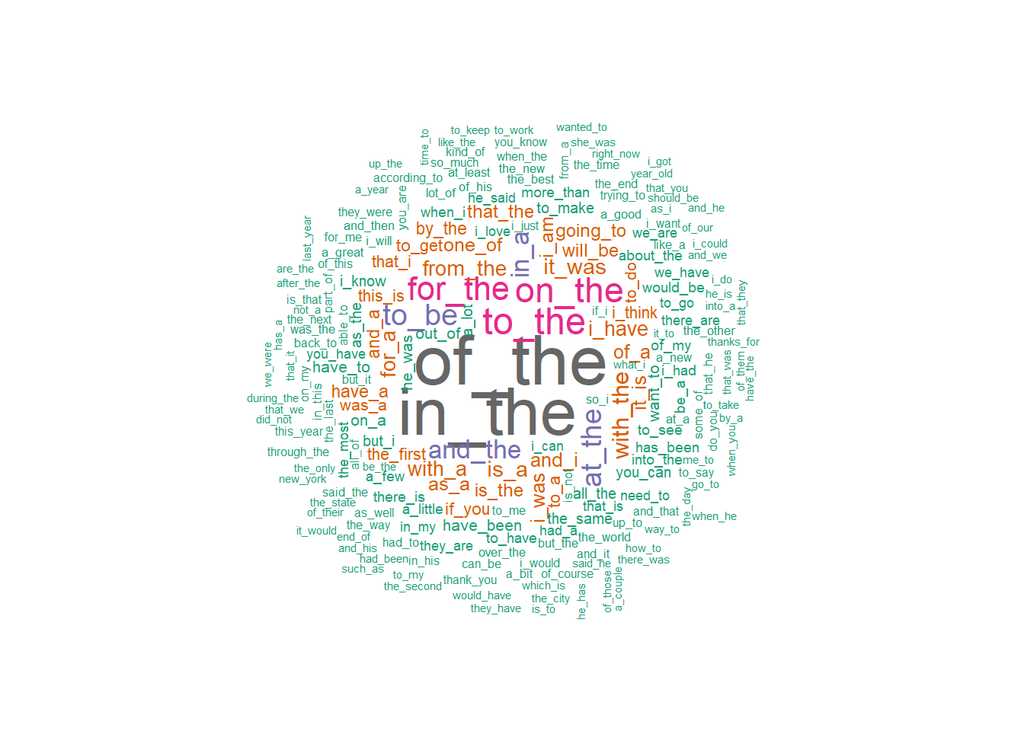

```r
#pairs of words
textplot_wordcloud(unig2_dfm, min_count=250, random_order= FALSE, rotation = .25, color = RColorBrewer::brewer.pal(8, "Dark2"), labelsize = 10)
```

The frequencies of words can also be plotted as follows:

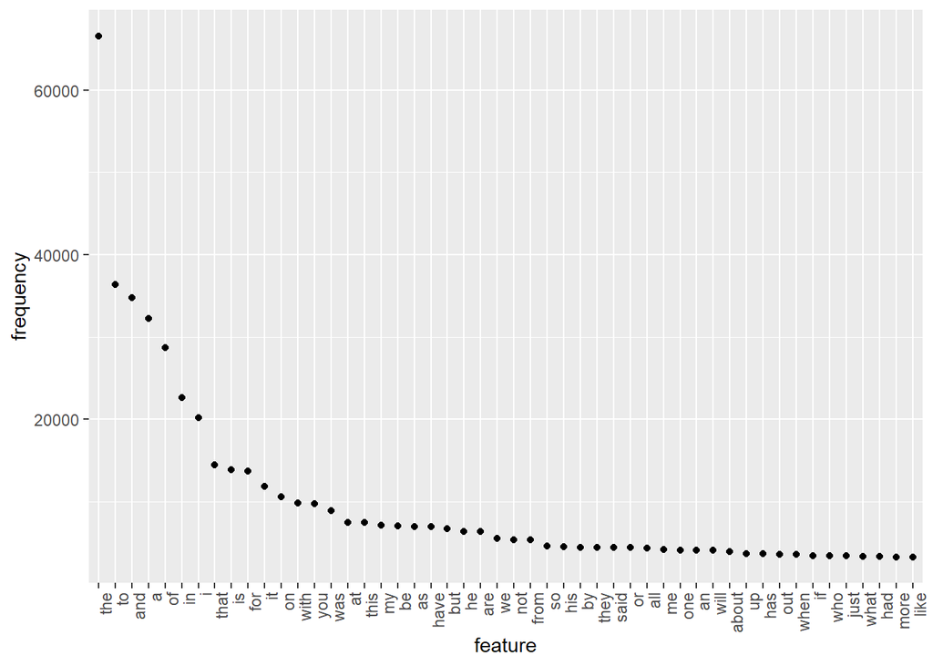

```r
#frequencies of words
feat_100<- textstat_frequency(unig_dfm, n=50)
feat_100$feature<-with(feat_100, reorder(feature, -frequency))
ggplot(feat_100, aes(x=feature, y=frequency))+geom_point()+theme(axis.text.x = element_text(angle=90, hjust=1))
```

Finally, the relative frequency of words from each source can be plotted. For informative purposes, the most common English words will be omitted. However, all words will be included in prediction models.

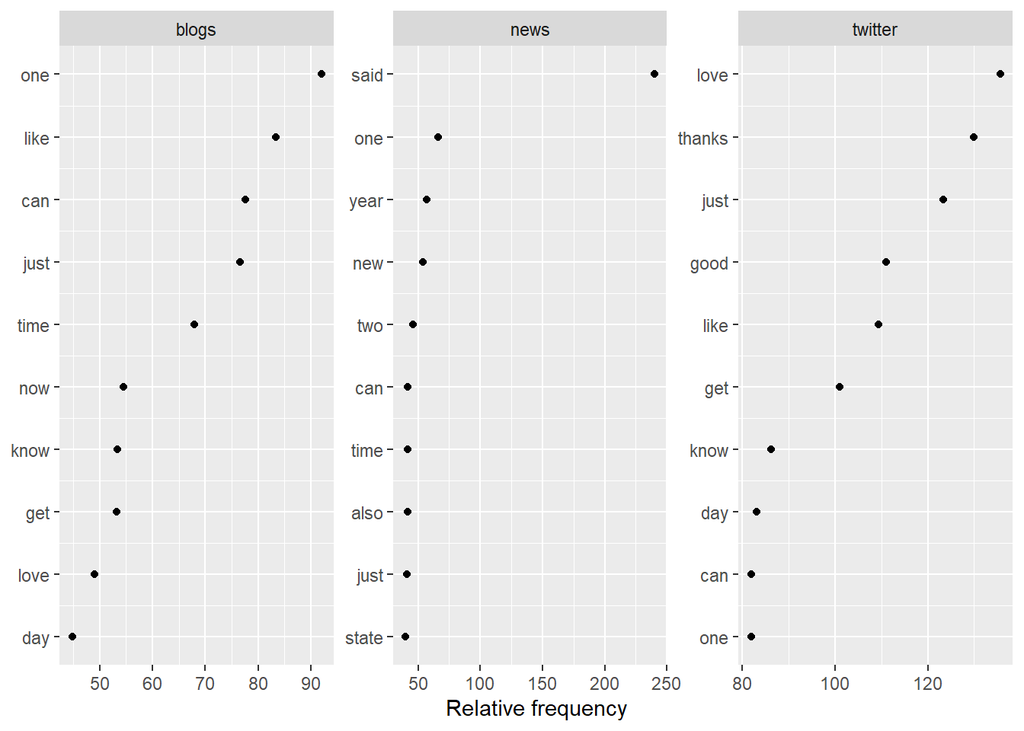

```r
#relative frequencies of words by source
dfm_weight_source<- total.corpus %>%
  tokens(remove_punct = TRUE,
         remove_symbols = TRUE,
         remove_numbers = TRUE,
         remove_url = TRUE,
         split_hyphens = TRUE) %>%
  tokens_remove(bad) %>%
  tokens_remove(stopwords("english")) %>%
  tokens_keep(pattern = "^[a-zA-Z]+$", valuetype = "regex") %>%
  dfm() %>%
  dfm_weight(scheme = "prop")

freq_weight<-textstat_frequency(dfm_weight_source, n=10, groups = dfm_weight_source$source)
ggplot(data = freq_weight, aes(x = nrow(freq_weight):1, y = frequency)) +
  geom_point() +
  facet_wrap(~ group, scales = "free") +
  coord_flip() +
  scale_x_continuous(breaks = nrow(freq_weight):1,
                     labels = freq_weight$feature) +
  labs(x = NULL, y = "Relative frequency")
```